WERBOS / BACKPROPAGATION

1 / 20

01 / PERSON & LEGACYWERBOS · BACKPROPAGATION · 01

# Paul Werbos는 누구인가?

역전파를 신경망 학습으로 연결한 연구자 · 생애와 이력

PW

[figure not shown]

사진: Rolf Kickuth, IJCNN 1991 · CC BY-SA 4.0

Paul John Werbos 1947년 출생

경제학·통계학·응용수학을 넘나들며 ‘기계는 어떻게 학습하는가’를 연구한 신경망 선구자

학력

1968 LSE 석사 · 1969 Harvard 석사 · 1974 Harvard 박사(통계학)

대표 연구

1974 Dynamic Feedback · 1981/1982 역전파의 신경망 응용

주요 경력

미국 에너지부 EIA 예측 모델 연구 · 미국 NSF 지능형 시스템 연구지원

수상

1995 IEEE Neural Network Pioneer Award · 2022 IEEE Frank Rosenblatt Award

그의 질문: 복잡한 예측 시스템의 수많은 매개변수를 어떻게 효율적으로 학습시킬 것인가?

**핵심**퍼셉트론의 발명자는 Rosenblatt, 역전파의 신경망 적용을 선구적으로 제안한 인물이 Werbos입니다.

김임환 · 신경망과 딥러닝의 기원원문 기반 강의 · 01 / 20

출처: IEEE ETHW, Werbos bio2017, NSS, IEEE 2022 Rosenblatt 수상자 기록. 사진 Wikimedia Commons Rolf Kickuth CC BY-SA 4.0.

02 / LEARNING QUESTIONWERBOS · BACKPROPAGATION · 02

# 신경망은 어떻게 스스로 배울까?

오늘 수업에서 답해야 할 한 가지 질문

### 질문 ①: 입력을 받으면 답은 어떻게 내나?

센서 값 → 가중치 곱셈 → 더하기 → 예측값

이것은 신경망의 정방향 계산(Forward Pass).

### 질문 ②: 틀린 답을 내면 어떻게 고치나?

정답과 비교 → 오차 계산 → 가중치 수정

이 과정에서 핵심 역할을 하는 것이 역전파(Backpropagation).

신경망이 “생각”하는 단계와 “배우는” 단계는 다릅니다.

**핵심**정방향은 예측, 역방향은 학습을 위한 미분 계산입니다.

김임환 · 신경망과 딥러닝의 기원원문 기반 강의 · 02 / 20

질문으로 시작: 학생들에게 “가중치를 어느 방향으로 얼마나 바꿀까요?”를 물어보십시오.

03 / HISTORYWERBOS · BACKPROPAGATION · 03

# 역전파의 역사는 한 사람의 발명만이 아니다

퍼셉트론 · 역방향 미분 · 신경망 학습을 구분해야 한다

**1958**

### Rosenblatt

퍼셉트론 학습

**1970**

### Linnainmaa

효율적인 역방향 자동미분

**1974**

### Werbos

Dynamic Feedback

**1981→82**

### Werbos

신경망 적용 논문화

**1986**

### Rumelhart 등

대중적 확산

“퍼셉트론의 탄생”과 “다층 신경망을 효율적으로 학습시키는 방법”은 서로 다른 역사입니다.

**핵심**Werbos의 중요한 공헌은 기존 수학적 미분 아이디어를 복잡한 예측·신경망 학습과 연결한 것입니다.

김임환 · 신경망과 딥러닝의 기원원문 기반 강의 · 03 / 20

Linnainmaa 1970년 역방향 AD, Werbos 1974/1982 신경망 관련 역사, Rumelhart/Hinton/Williams 1986. 최초라는 표현을 조심.

04 / PRIMARY SOURCEWERBOS · BACKPROPAGATION · 04

# 1974년 원논문은 어떤 연구인가?

제목부터 확인하자: “Beyond Regression” = 회귀분석을 넘어서

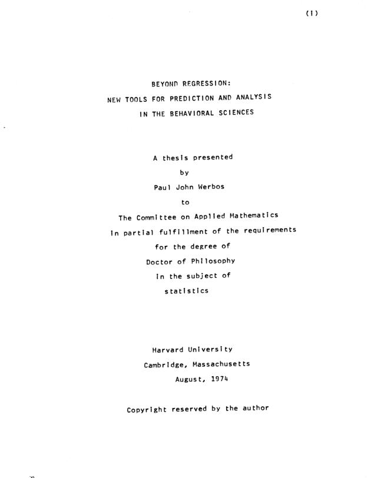

첨부 원문 · Harvard 박사논문 표지 · 1974

1974 · Ph.D. THESIS

Beyond Regression

New Tools for Prediction and Analysis in the Behavioral Sciences

저자: Paul John Werbos / Harvard University

전공: Statistics · Committee on Applied Mathematics

문제의식: 선형 회귀를 넘어 복잡한 비선형 예측 모델을 어떻게 추정할까?

핵심 장: Chapter II · Dynamic Feedback, Statistical Estimation and Systems Optimization

**핵심**1974년 연구 전체가 “현대식 다층 퍼셉트론 구현 논문”인 것은 아닙니다.

김임환 · 신경망과 딥러닝의 기원원문 기반 강의 · 04 / 20

원문 Harvard 1974 thesis 453 PDF pages, cover + table of contents + Ch. II. 사용자가 첨부한 논문 페이지 이미지 사용.

05 / THE PROBLEMWERBOS · BACKPROPAGATION · 05

# 복잡한 모델은 왜 학습이 어려울까?

일반 회귀에서 비선형·동적 시스템으로

### 기존 회귀분석

y = a x + b

비교적 단순한 함수 형태

매개변수 수가 적으면 추정이 쉬움

복잡한 상호작용·시간 의존성 표현에 한계

### Werbos가 고민한 문제

x(t+1) = f(x(t), u(t))

비선형 관계, 과거 상태, 반복 계산

변수가 많아지면 미분 계산이 복잡해짐

그래서 기울기를 효율적으로 구해야 함

문제의 핵심은 “복잡한 모델의 예측”이 아니라 “복잡한 모델을 학습시키는 계산 비용”이었습니다.

**핵심**비선형/시계열 예측을 동기로 설명하되 1974 논문의 모든 내용을 신경망만으로 축소하지 않습니다.

김임환 · 신경망과 딥러닝의 기원원문 기반 강의 · 05 / 20

예시: x(t+1)=f(x(t),u(t)) 표기는 1981/82 후속 논문 Figure 1에도 등장.

06 / CENTRAL IDEAWERBOS · BACKPROPAGATION · 06

# Werbos의 아이디어: 계산을 거꾸로 따라가기

한 번 계산한 경로를 역방향으로 이용해 미분한다

**1**

### Forward

왼쪽에서 오른쪽으로 예측값 계산

**2**

### Loss

정답과 비교해 손실 계산

**3**

### Backward

손실을 줄이도록 각 가중치의 기울기를 계산

**핵심**Backpropagation은 가중치를 직접 바꾸는 모든 최적화 알고리즘의 동의어가 아닙니다. 먼저 미분을 얻고, 그 다음 업데이트합니다.

김임환 · 신경망과 딥러닝의 기원원문 기반 강의 · 06 / 20

실제로 오류 숫자 자체를 물리적으로 흘려보내는 장치가 아니라 연쇄법칙을 이용한 편미분 계산으로 이해시키십시오.

07 / 1974 COREWERBOS · BACKPROPAGATION · 07

# 1974년 논문의 세 가지 열쇠

Ordered Derivatives → Dynamic Feedback → Optimization

### ① Ordered Derivatives

계산 순서가 정해진 함수에서 전체 미분을 체계적으로 구함

### ② Dynamic Feedback

결과에서 원인 방향으로 민감도 정보를 계산함

### ③ Optimization

얻은 기울기로 손실을 작게 만드는 매개변수 탐색

### 1974년 논문에서 실제로 확인되는 내용

Chapter II: “Dynamic Feedback, Statistical Estimation and Systems Optimization”

Section (xii): “The Ordered Derivative and Dynamic Feedback”

비선형 시스템, 기억(시계열), 추정·최적화 문제로 논의를 전개

**핵심**논문 목차 기반. 현대식 강의의 “forward/backward”와 원문의 “dynamic feedback/ordered derivative”를 혼동하지 않도록 한다.

김임환 · 신경망과 딥러닝의 기원원문 기반 강의 · 07 / 20

목차의 원문 장·절 제목을 그대로 인용/요약, 첨부 1974년 PDF 기반.

08 / PRIMARY SOURCEWERBOS · BACKPROPAGATION · 08

# 1981/1982 후속 논문의 정체

Applications of Advances in Nonlinear Sensitivity Analysis

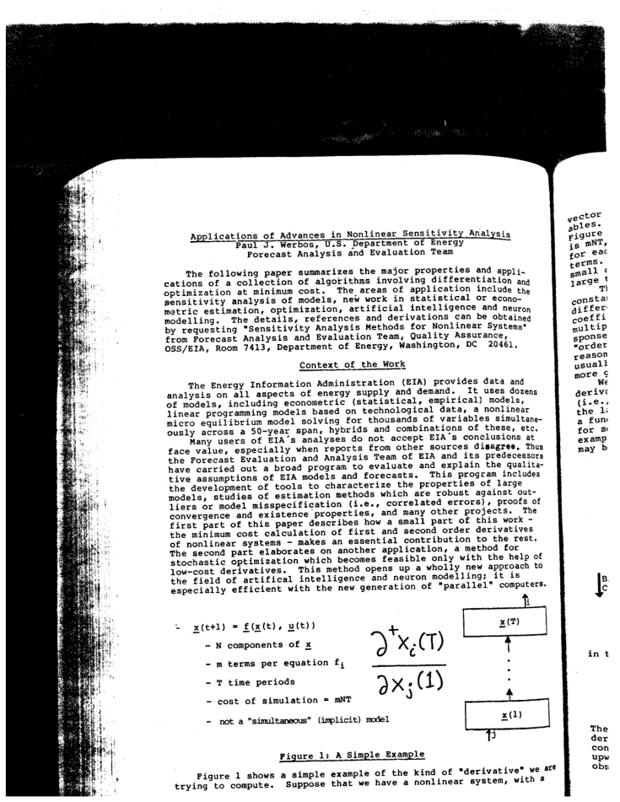

첨부 원문 · Applications of Advances in Nonlinear Sensitivity Analysis

1981 발표 · 1982 출판

논문에서 신경망으로 이어진다

발표: IFIP Conference on System Modeling and Optimization (1981)

출판: Springer Lecture Notes in Control and Information Sciences 38, pp. 762–770 (1982)

소속: U.S. Department of Energy, Forecast Analysis and Evaluation Team

핵심: Nonlinear Sensitivity Analysis와 효율적 미분의 신경망 응용

참고: 첨부 PDF는 10페이지 스캔본이며, 인쇄본 페이지는 762–770입니다.

**핵심**논문 작성/발표연도(1981)와 출판연도(1982)를 구분하고 원본 편집된 10페이지 스캔과 인쇄본 페이지를 혼동하지 말 것.

김임환 · 신경망과 딥러닝의 기원원문 기반 강의 · 08 / 20

첨부 1981 PDF 앞표지에 Springer 1982, pp. 762–770. 원문 초록 첫 단락에 AI와 neuron modelling 포함.

09 / ORIGINAL FIGUREWERBOS · BACKPROPAGATION · 09

# 원문 765쪽: 바로 이 그림이다

현대적 Backpropagation의 수학적 핵심이 보이는 페이지

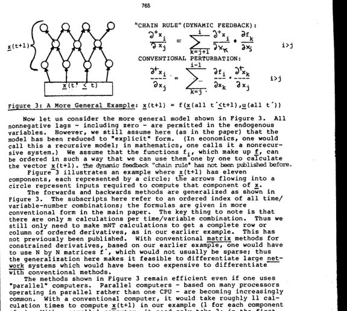

1982 출판본 p.765 · Figure 3 + CHAIN RULE

원문 그림을 자세히 보자

계산망(신경망) + 미분 연쇄법칙

연결된 원 하나하나가 계산 단위

앞으로 계산되는 결과는 여러 층을 통과함

뒤로 계산하면 모든 연결이 결과에 미치는 영향을 구할 수 있음

논문 p.765: “CHAIN RULE (DYNAMIC FEEDBACK)”

그림은 원문 그대로, 오른쪽 해설은 교육용 재구성입니다.

**핵심**Figure 3에서 저자는 layered network, ordered derivatives, chain rule (dynamic feedback)를 설명함.

김임환 · 신경망과 딥러닝의 기원원문 기반 강의 · 09 / 20

논문 인쇄본 p.765 Figure 3. 인용 원문 짧게 유지.

10 / CHAIN RULEWERBOS · BACKPROPAGATION · 10

# 역전파 수학은 생각보다 단순하다

연쇄법칙(Chain Rule): 경로를 따라서 미분을 곱하기

### 고등학교 미분으로 이해하는 연쇄법칙

h = w₁x → ŷ = w₂h → L = ½(ŷ − y)²

∂L/∂w₁ = (∂L/∂ŷ) × (∂ŷ/∂h) × (∂h/∂w₁)

즉, “최종 오차가 첫 번째 가중치에 얼마나 민감한지”를 중간 단계를 따라 곱한다.

아주 복잡한 신경망이라도 ‘작은 미분들을 뒤로 곱해가는 방식’으로 학습 방향을 알 수 있습니다.

**핵심**기호가 어려우면 “왼쪽 매개변수를 1% 바꾸면 최종 오차가 얼마나 변하나?”라고 바꿔 질문한다.

김임환 · 신경망과 딥러닝의 기원원문 기반 강의 · 10 / 22

수식은 원문 원리의 초간단 2단 선형 예제 재구성. 원문 자체의 실험 결과를 재현한 것이 아님.

11 / WORKED EXAMPLE 1WERBOS · BACKPROPAGATION · 11

# 숫자로 해보자 ① 정방향 계산

아직 학습 전: 두 개의 가중치로 예측을 만들어 본다

가정: x = 2, w₁ = 3, w₂ = 4, 정답 y = 20 · 손실 L = ½(ŷ − y)²

**핵심**학생들에게 손실 8을 먼저 스스로 계산하도록 하십시오. 단순 선형 2단 모델을 이용한 설명용 예제입니다.

김임환 · 신경망과 딥러닝의 기원원문 기반 강의 · 11 / 22

설명용 단순 수치 예제, 논문에 나온 실험/데이터가 아님.

12 / ERROR VS LOSSWERBOS · BACKPROPAGATION · 12

# 오차는 4인데 왜 손실은 8일까?

오차(Error)는 실제 차이, 손실(Loss)은 그 차이를 학습용 점수로 바꾼 값

가정: 입력 x = 2 · 첫 가중치 w₁ = 3 · 두 번째 가중치 w₂ = 4 · 정답 y = 20

① 중간 계산

h = 3 × 2

**6**

h = w₁x · 은닉층의 출력

② 최종 예측

ŷ = 4 × 6

**24**

ŷ = w₂h · 모델의 예측

③ 오차(Error)

e = 24 − 20

**+4**

정답과의 실제 차이

④ 손실(Loss)

L = ½ × 4²

**8**

오차를 제곱해 만든 학습 점수

**오차 = 4**“예측이 정답보다 4만큼 큽니다.”

**손실 = 8**“이 오차에 부여한 학습용 벌점이 8입니다.”

**핵심**손실 8은 오차가 8이라는 뜻이 아닙니다. 오차는 여전히 4이며, 손실은 최적화에 사용하는 별도의 수치입니다.

김임환 · 신경망과 딥러닝의 기원설명용 수치 예제 · 12 / 22

수업용으로 만든 선형 2단 예제이며 Werbos 원논문의 실험 결과가 아닙니다. 오차는 부호를 가진 e=ŷ−y=+4, 오차의 절댓값은 |e|=4. 손실은 선택한 손실함수에 따라 달라집니다. 손실의 크기만으로 실제 오차 단위를 해석하면 안 됩니다.

13 / LOSS FUNCTIONWERBOS · BACKPROPAGATION · 13

# 왜 오차를 제곱하고 ½을 곱할까?

L = ½e² : 큰 오차에는 더 큰 벌점을, 미분할 때는 간단한 수식을

### 오차 e와 손실 L의 관계

[figure not shown]

e = −4와 +4 모두 손실은 8 · 오차가 2배면 손실은 4배

① 제곱(e²)을 하는 이유

(+4)² = (−4)² = 16

예측이 크든 작든 손실은 0 이상입니다. 특히 큰 오차에 더 큰 벌점을 줍니다.

② 앞에 ½을 붙이는 이유

d(½e²)/de = e

미분할 때 나오는 2가 ½과 상쇄됩니다. 그래서 역전파 계산이 더 간단해집니다.

|e| = 1 → L = 0.5|e| = 2 → L = 2|e| = 4 → L = 8

**핵심**손실 8 자체보다 중요한 것은 미분값입니다. 다음 장에서 미분의 연쇄법칙으로 w₂의 기울기 24, w₁의 기울기 32를 구합니다.

김임환 · 신경망과 딥러닝의 기원설명용 수치 예제 · 13 / 22

MSE의 단일 표본형 L=(1/2)e². 1/2은 미분을 편리하게 하려고 쓴 상수이며 꼭 이 손실함수를 쓸 필요는 없습니다. 분류 문제에서는 교차엔트로피 등 다른 손실함수를 사용합니다. L=8은 정량적 성능 해석에서 오차의 절댓값과 직접 비교하는 물리적 수치가 아닙니다. 미분 시 dL/de=e=4, 이후 ∂L/∂w2=e h=24, ∂L/∂w1=e w2 x=32.

14 / WORKED EXAMPLE 2WERBOS · BACKPROPAGATION · 14

# 숫자로 해보자 ② 역방향 계산

손실을 미분하면 각 가중치를 어느 방향으로 조정해야 하는지 알 수 있다

### 뒤에서 먼저

∂L/∂ŷ = ŷ − y = 4

예측값이 정답보다 4만큼 큽니다.

w₂가 오차에 미치는 기여

∂L/∂w₂ = 4 × h = 24

### 한 층 더 거꾸로

∂L/∂h = 4 × w₂ = 16

오차가 앞의 은닉 계산에 어떻게 전달되는지 구합니다.

w₁이 오차에 미치는 기여

∂L/∂w₁ = 16 × x = 32

최종 결과에 가까운 가중치부터 거꾸로 미분하면 앞단 가중치의 기울기도 효율적으로 얻습니다.

**핵심**연쇄법칙으로 출력층부터 입력층까지 기울기를 전달하면 모든 가중치의 수정 방향을 알 수 있습니다.

김임환 · 신경망과 딥러닝의 기원원문 기반 강의 · 14 / 22

설명용 수치 예제.

15 / WORKED EXAMPLE 3WERBOS · BACKPROPAGATION · 15

# 숫자로 해보자 ③ 가중치 업데이트

역전파는 미분을 계산하고, 경사하강법이 실제로 가중치를 바꾼다

**기존**

### w₁ = 3

w₂ = 4 · 예측값 24 · 손실 8

**학습률**

### η = 0.01

w ← w − η × (기울기)

**수정 뒤**

### w₁ = 2.68

w₂ = 3.76 · 예측값 20.1536

### 학습 전후: 정답이 20일 때

학습 전 오차**4.0000**

→

1회 수정 후 오차**0.1536**

**핵심**신경망에는 비선형 활성화 등이 필요할 수 있음. 이 예제는 오직 기울기 계산 원리 설명용입니다. 손실은 8에서 약 0.0118로 감소.

김임환 · 신경망과 딥러닝의 기원원문 기반 강의 · 15 / 22

손실 재계산: 1/2*(0.1536)^2=0.01179648. η=.01.

16 / PERCEPTRON VS MLPWERBOS · BACKPROPAGATION · 16

# 퍼셉트론과 다층 신경망의 차이

학습 자체가 처음 가능해진 것이 아니라, “깊은 연결 구조의 학습”이 실용화됐다

퍼셉트론은 단층에서도 가중치를 학습할 수 있습니다.

다층 모델은 앞단 가중치의 오차 기여를 계산하는 방법이 필요합니다.

**핵심**단층 퍼셉트론도 학습 규칙이 있으며, 1974년 이전에 다층 학습 시도도 존재. “Werbos가 최초 퍼셉트론 적용”이라고 표현하지 않는다.

김임환 · 신경망과 딥러닝의 기원원문 기반 강의 · 16 / 22

Rosenblatt의 원 업적과 Werbos 기여를 과장 없이 구분.

17 / COMPUTATIONAL INSIGHTWERBOS · BACKPROPAGATION · 17

# 왜 이것이 결정적인 돌파구였을까?

“잘 맞출 수 있는 함수”를 만드는 것만으로는 부족하다

### 순진한 방법: 가중치를 하나씩 변화시켜보기

가중치 1,000개 → 많은 반복 계산

각 가중치를 조금씩 바꿔 손실 변화량을 측정하면 계산 비용이 큽니다.

### 역전파: 한 번의 역방향 계산

연쇄법칙을 재사용 → 한꺼번에 기울기 계산

미리 계산한 중간 결과를 재사용하여 모든 가중치의 기울기를 효율적으로 얻습니다.

논문이 강조한 핵심은 정교한 모델을 학습할 수 있도록 “미분 계산의 비용”을 낮추는 것입니다.

**핵심**엄밀히 “상수 시간”은 아닙니다. 모든 가중치의 기울기를 구하는 계산량이 모델 계산량과 같은 차수로 수행되는 점이 중요합니다.

김임환 · 신경망과 딥러닝의 기원원문 기반 강의 · 17 / 22

1981/82 논문: low-cost derivatives / minimal cost calculation, with many parameter derivatives.

18 / RESEARCH HISTORYWERBOS · BACKPROPAGATION · 18

# 1986년 논문은 왜 다시 중요한가?

아이디어가 알려지는 것과 널리 재현되는 것은 다르다

### Werbos (1974 → 1982)

개념과 일반적 계산 방법 제시

순서 있는 계산의 미분

비선형 동적 모델

신경망에 대한 적용 가능성

### Rumelhart · Hinton · Williams (1986)

학습 성능의 설득력 있는 시연과 확산

다층 신경망의 내부 표현 학습

학습 실험과 명확한 소개

역전파의 폭넓은 보급

연구의 ‘기원’, ‘구현’, ‘실증’, ‘대중화’는 다른 종류의 기여입니다.

**핵심**Werbos의 수학적 기여와 1986년의 학습 시연·대중화는 모두 신경망 발전에 중요합니다.

김임환 · 신경망과 딥러닝의 기원원문 기반 강의 · 18 / 22

역사적 단정과 우선권 논쟁을 부풀리지 말고 단계별 역할로 설명한다.

19 / SEMICONDUCTOR CASEWERBOS · BACKPROPAGATION · 19

# 반도체 공정 데이터와 연결해 보자

오래된 수학이 왜 지금도 필요한가?

### 공정 센서 데이터 예시

입력: 온도 · 압력 · 가스 유량

출력: 불량 확률(0~1)

손실: 예측 확률과 실제 합격/불합격의 차이

학습: 손실을 줄이도록 가중치 수정

공정 데이터 → 은닉층 → 불량 확률

Werbos의 수학은 오늘날 반도체 불량 예측 신경망을 학습시키는 과정에도 쓰입니다.

**핵심**구체적인 SECOM 데이터의 모델 성능을 주장하지 않는다. 딥러닝에 쓰이는 역전파의 일반적인 응용 예제만 든다.

김임환 · 신경망과 딥러닝의 기원원문 기반 강의 · 19 / 22

이해 예시이며 Werbos 원논문에 등장하는 반도체 데이터 실험이 아닙니다.

20 / LIMITATIONSWERBOS · BACKPROPAGATION · 20

# 역전파를 배우면 모든 문제가 해결될까?

가능하게 만든 것과 여전히 어려운 것을 구분

### 강점

매개변수가 많은 모델의 미분 계산

미분 가능한 여러 연산을 연결

분류·회귀·영상 모델의 학습을 지원

### 주의점

좋은 데이터와 올바른 검증이 필요

과적합·학습률·기울기 소실/폭주 가능

설명력·일반화 성능을 자동 보장하지 않음

역전파는 “학습을 계산하는 도구”이지 “반드시 좋은 답을 얻는 보증서”는 아닙니다.

**핵심**1950-80년대 기여와 현대 딥러닝의 성능이 동치라는 오해를 방지한다.

김임환 · 신경망과 딥러닝의 기원원문 기반 강의 · 20 / 22

현대 관점 확장 설명. 첨부 1974·1981 원논문의 직접적인 실험 결론은 아님.

21 / CLASS DISCUSSIONWERBOS · BACKPROPAGATION · 21

# 오늘 배운 내용을 확인해 봅시다

세 가지 질문으로 마무리

**Q1**

### 역전파는 무엇을 계산하나?

예측값 / 가중치의 기울기 / 정답 데이터 중 선택

**Q2**

### 왜 뒤로 계산하나?

모든 매개변수의 기울기를 효율적으로 구하기 위해

**Q3**

### 누가 무엇을 했나?

1958 퍼셉트론 · 1974/82 Werbos · 1986 확산

### 3분 활동: 학생들에게 한 문장으로 말해보게 하기

“입력 → 예측 → 오차 → 역방향 미분 → 가중치 수정”을 반도체 불량 예측에 적용해 설명해 보세요.

**핵심**Q1 정답은 가중치의 기울기. Q2 역전파의 핵심은 연쇄법칙으로 중간 계산 재활용. Q3 학문사 우선권 구분.

김임환 · 신경망과 딥러닝의 기원원문 기반 강의 · 21 / 22

학생에게 과제로 정방향과 역방향 두 화살표를 직접 그려보게 할 수 있습니다.

22 / READ THE ORIGINALWERBOS · BACKPROPAGATION · 22

# 논문과 참고자료 · 원문을 직접 읽어보자

업로드하신 두 원문을 중심으로 구성하고, 외부 자료는 생애·역사 확인에만 사용

1 · 1974 원문

Paul J. Werbos, Beyond Regression: New Tools for Prediction and Analysis in the Behavioral Sciences, Harvard Ph.D. thesis (1974).

[원문](https://gwern.net/doc/ai/nn/1974-werbos.pdf)

2 · 1981/82 원문

Paul J. Werbos, Applications of Advances in Nonlinear Sensitivity Analysis, IFIP 1981 / Springer 1982, pp. 762–770.

[DOI](https://doi.org/10.1007/BFb0006203)

3 · 후속 연구

Rumelhart, Hinton & Williams, Learning representations by back-propagating errors, Nature 323, 533–536 (1986).

[DOI](https://doi.org/10.1038/323533a0)

4 · 저자 이력

IEEE ETHW · NSS Werbos Biography · IEEE Frank Rosenblatt Award (2022) · Werbos bio2017.

[IEEE](https://ethw.org/Paul_John_Werbos)

5 · 사진

Paul Werbos at IJCNN Seattle, July 8, 1991. Photo: Rolf Kickuth, Wikimedia Commons, CC BY-SA 4.0.

[출처](https://commons.wikimedia.org/wiki/File:PaulWerbos-IJCNNseattle1991-07-08.jpg)

**핵심**원문에 없는 현대적 설명용 예제는 “교육용 재구성”으로 구분했습니다.

김임환 · 신경망과 딥러닝의 기원원문 기반 강의 · 22 / 22

원문 스캔 도판은 사용자가 제공한 자료에서 발췌. 위 자료들은 참고 연구 링크.

**교수자 노트**